# HW4_New_RMD

Leo Shr

2022/1/12

`{r} rm(list=ls())`

```r
#install.packages('zoo')
require(zoo)
library(data.table)
```

```r
require(ggplot2)
library(dplyr)
require(tidyverse)
require(rmarkdown)
library(lubridate)
library(tidyverse)
library(dplyr)
#install.packages("factoextra")
library(factoextra)
#install.packages('DescTools')
require(DescTools)
```

1. Import and Examine the Data
1. Import the CSV file into R using fread() and take a look at the data Import Data & dim

```r
retail  <- fread('onlineRetail.csv')

dim(retail)
```

```
## [1] 541909      8
```

Summary:

```r
summary(retail)
```

```
##   InvoiceNo          StockCode         Description           Quantity
##  Length:541909      Length:541909      Length:541909      Min.   :-80995.00
##  Class :character   Class :character   Class :character   1st Qu.:     1.00
##  Mode  :character   Mode  :character   Mode  :character   Median :     3.00
##                                                           Mean   :     9.55
##                                                           3rd Qu.:    10.00
##                                                           Max.   : 80995.00
##
##  InvoiceDate          UnitPrice           CustomerID       Country
##  Length:541909      Min.   :-11062.06   Min.   :12346    Length:541909
##  Class :character   1st Qu.:     1.25   1st Qu.:13953    Class :character
##  Mode  :character   Median :     2.08   Median :15152    Mode  :character
##                     Mean   :     4.61   Mean   :15288
##                     3rd Qu.:     4.13   3rd Qu.:16791
##                     Max.   : 38970.00   Max.   :18287
##                                         NA's   :135080
```

head:

```r
head(retail)
```

```
##    InvoiceNo StockCode                         Description Quantity
## 1:    536365    85123A  WHITE HANGING HEART T-LIGHT HOLDER        6
## 2:    536365     71053                 WHITE METAL LANTERN        6
## 3:    536365    84406B      CREAM CUPID HEARTS COAT HANGER        8
## 4:    536365    84029G KNITTED UNION FLAG HOT WATER BOTTLE        6
## 5:    536365    84029E      RED WOOLLY HOTTIE WHITE HEART.        6
## 6:    536365     22752        SET 7 BABUSHKA NESTING BOXES        2
##     InvoiceDate UnitPrice CustomerID        Country
## 1: 12/1/10 8:26      2.55      17850 United Kingdom
## 2: 12/1/10 8:26      3.39      17850 United Kingdom
## 3: 12/1/10 8:26      2.75      17850 United Kingdom
## 4: 12/1/10 8:26      3.39      17850 United Kingdom
## 5: 12/1/10 8:26      3.39      17850 United Kingdom
## 6: 12/1/10 8:26      7.65      17850 United Kingdom
```

**(b) Examine the data by printing out the unique number of customers, the unique number of products purchased, as well as the unique number of transactions.**

**Preprocessing Data cleaning**

**Issues:**

- 1. The negative value of Quantity reflects the returned purchase,and it should not be removed because the returned products are not able to be resale.
- 2. NA value in CustomerID: this part is trash cuz we are required to group data by clientID.Therefore, we should drop them .

```r
sum(is.na(retail))# [1] 133361
```

```
## [1] 135080
```

```r
retail <- retail %>% drop_na()
```

```r
sum(is.na(retail))#[1] 0 , good!
```

```
## [1] 0
```

- 3. UnitPrice: The product price per unit in sterling (£). However, we got negative sold price It can be solved by elimate the NA client ID.It seems that the most negative shopping record were include in the observation with no customerID

**CustomerID:**

```r
length(unique(retail$CustomerID)) # [1] 4372
```

```
## [1] 4372
```

**StockCode:**

```r
length(unique(retail$StockCode)) # [1] 3684
```

```
## [1] 3684
```

**InvoiceNo:**

```r
length(unique(retail$InvoiceNo )) # [1] 22190
```

```
## [1] 22190
```

**(2) Compute the RFM Variables**

- 3. Convert the InvoiceDate into a date obj. then create a variable called Recency by computing the number of days until the last day of purchase in the dataset (i.e., Dec. 09, 2011) since last purchase for each customer.

Convert the InvoiceDate into a date obj. THen change the time into mdy_hm format then

```r
data2<-retail
data2$InvoiceDate <- as.Date(mdy_hm(data2$InvoiceDate))
head(data2,3)
```

```
##    InvoiceNo StockCode                        Description Quantity InvoiceDate
## 1:    536365    85123A WHITE HANGING HEART T-LIGHT HOLDER        6  2010-12-01
## 2:    536365     71053                WHITE METAL LANTERN        6  2010-12-01
## 3:    536365    84406B     CREAM CUPID HEARTS COAT HANGER        8  2010-12-01
##    UnitPrice CustomerID        Country
## 1:      2.55      17850 United Kingdom
## 2:      3.39      17850 United Kingdom
## 3:      2.75      17850 United Kingdom
```

#### (d) Create a variable called Recency, Frequency and Monetary for each customer in the data.

```r
data2.1<- data2
data2.2<-data2.1 %>%mutate(Amount = UnitPrice  * Quantity )
#For the Monetary counting

head(data2.2,3)
```

```
##    InvoiceNo StockCode                        Description Quantity InvoiceDate
## 1:    536365    85123A WHITE HANGING HEART T-LIGHT HOLDER        6  2010-12-01
## 2:    536365     71053                WHITE METAL LANTERN        6  2010-12-01
## 3:    536365    84406B     CREAM CUPID HEARTS COAT HANGER        8  2010-12-01
##    UnitPrice CustomerID        Country Amount
## 1:      2.55      17850 United Kingdom  15.30
## 2:      3.39      17850 United Kingdom  20.34
## 3:      2.75      17850 United Kingdom  22.00
```

```r
# "2011-12-09" the newest shopping record of the clients
# 最近有任何客人消費的時間(全部資料最後一筆)
max_date_per_user <- max(data2.2$InvoiceDate);max_date_per_user
```

```
## [1] "2011-12-09"
```

```r
temp = data2.2 %>%
    group_by(CustomerID);head(temp,3)
```

```
## # A tibble: 3 x 9
## # Groups:   CustomerID [1]
##   InvoiceNo StockCode Description      Quantity InvoiceDate UnitPrice CustomerID
##   <chr>     <chr>     <chr>               <int> <date>          <dbl>      <int>
## 1 536365    85123A    WHITE HANGING H~        6 2010-12-01       2.55      17850
## 2 536365    71053     WHITE METAL LAN~        6 2010-12-01       3.39      17850
## 3 536365    84406B    CREAM CUPID HEA~        8 2010-12-01       2.75      17850
## # ... with 2 more variables: Country <chr>, Amount <dbl>
```

#### Note:

- Monetary: it’s USD, therefore we set it as float(bouble), 消費金額
- frequent= shopping count
- Recency: 是距離當期營業日的該客戶最近消費距離多久 最近有客人消費時間- 該client最靠近現在的消費時間

```r
RFM <- data2.2 %>%
    group_by(CustomerID) %>%
    summarise(Monetary = as.double(sum(Amount)),
              Frequency = n(),
              Recency = max_date_per_user- max(InvoiceDate))

head(RFM,3)
```

```
## # A tibble: 3 x 4
##   CustomerID Monetary Frequency Recency
##        <int>    <dbl>     <int> <drtn>
## 1      12346       0          2 325 days
## 2      12347    4310        182   2 days
## 3      12348    1797.        31  75 days
```

```r
str(RFM)
```

```
## tibble [4,372 x 4] (S3: tbl_df/tbl/data.frame)
##  $ CustomerID: int [1:4372] 12346 12347 12348 12349 12350 12352 12353 12354 12355 12356 ...
##  $ Monetary  : num [1:4372] 0 4310 1797 1758 334 ...
##  $ Frequency : int [1:4372] 2 182 31 73 17 95 4 58 13 59 ...
##  $ Recency   : 'difftime' num [1:4372] 325 2 75 18 ...
##   ..- attr(*, "units")= chr "days"
```

- (3-e) Visualize the RFM variables with box plots.

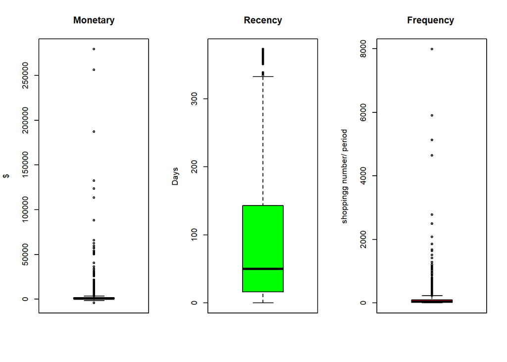

```r
RFM_3 <- RFM
par(mfrow = c(1,3))
boxplot(RFM_3$Monetary,
        main = "Monetary",
        ylab = "$",
        horizontal = FALSE,
        col = "blue")
boxplot(RFM_3$Recency,
        main = "Recency",
        ylab = "Days",
        horizontal = FALSE,
        col = "green")

boxplot(RFM_3$Frequency ,
        main = "Frequency ",
        ylab = "shoppingg number/ period",
        horizontal = FALSE,
        col = "red")
```

- (3-f) It seems that there are extreme values in the RFM variables.

**Remove these extreme values/outliers by keeping only the values that are within the 99th percentile.**

kindly remind that the function Winsorize is different from the filter method, it replaces the extreme value by not the extreme one, which is the suggested method. Because in the process of the fitting model, we want the probability of outlier being selected as starting clustering by kmeans model is as small as it can. Then, Winsorize function replacing the outlier with the not extreme value would make the probability distribution of the data more centralized(Variance decreasing) than the original one. Hence, the probability of the outlier being selected as clustriod becomes slower.

```r
RFM_3.1 <- RFM_3
RFM_3.1_ = RFM_3.1 %>% mutate(Recency =as.numeric(RFM_3.1$Recency))

##filter method provided here
# No_outlier <- RFM_3.1_ %>% filter(Frequency <= quantile(Frequency, .99)) %>%
#     filter(Monetary <= quantile(Monetary, .99)) %>%
#     filter(Recency <= quantile(Recency, .99))

No_outlier <- RFM_3.1_ %>%
    mutate(Monetary   = Winsorize(Monetary  , minval = quantile(Monetary  , 0.01),
                                  maxval = quantile(Monetary, 0.99), probs = c(0.01, 0.99)),
           Frequency  = Winsorize(Frequency  , minval = quantile(Frequency  , 0.01),
                                  maxval = quantile(Frequency, 0.99), probs = c(0.01, 0.99)),
           Recency    = Winsorize(Recency  , minval = quantile(Frequency  , 0.01),
                                  maxval = quantile(Recency, 0.99), probs = c(0.01, 0.99)))
head(RFM_3.1_)
```

```
## # A tibble: 6 x 4
##   CustomerID Monetary Frequency Recency
##        <int>    <dbl>     <int>   <dbl>
## 1      12346       0          2     325
## 2      12347    4310        182       2
## 3      12348    1797.        31      75
## 4      12349    1758.        73      18
## 5      12350     334.        17     310
## 6      12352    1545.        95      36
```

```r
RFM_3.f_ans <- No_outlier
```

```r
nrow(RFM_3.1_)#[1] 4372
```

```
## [1] 4372
```

```r
nrow(No_outlier)#[1] 4241
```

```
## [1] 4372
```

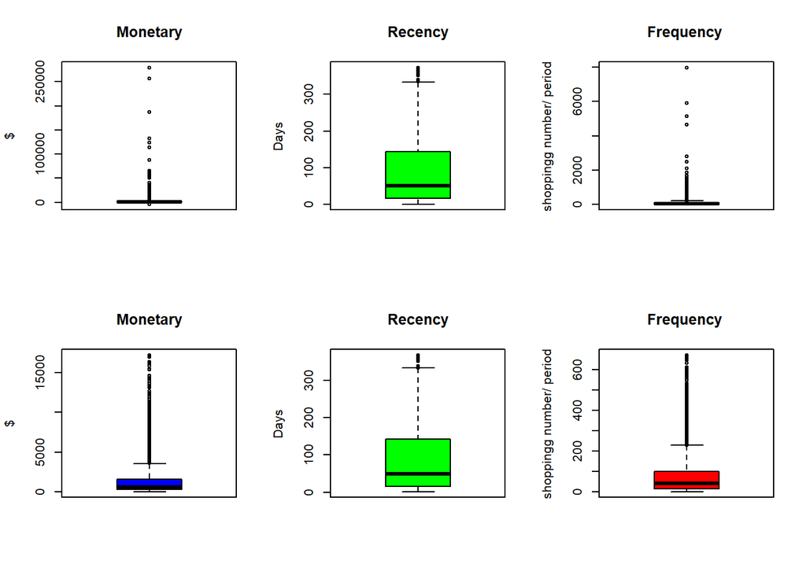

```r
par(mfrow = c(2,3))


boxplot(RFM_3$Monetary,
        main = "Monetary",
        ylab = "$",
        horizontal = FALSE,
        col = "blue")
boxplot(RFM_3$Recency,
        main = "Recency",
        ylab = "Days",
        horizontal = FALSE,
        col = "green")

boxplot(RFM_3$Frequency ,
        main = "Frequency ",
        ylab = "shoppingg number/ period",
        horizontal = FALSE,
        col = "red")
boxplot(RFM_3.f_ans$Monetary,
        main = "Monetary",
        ylab = "$",
        horizontal = FALSE,
        col = "blue")
boxplot(RFM_3.f_ans$Recency,
        main = "Recency",
        ylab = "Days",
        horizontal = FALSE,
        col = "green")

boxplot(RFM_3.f_ans$Frequency ,
        main = "Frequency ",
        ylab = "shoppingg number/ period",
        horizontal = FALSE,
        col = "red")
```

**(4) Scaling the Variables** - (g) To prep the data for clustering, we will need to scale the features/variables. Create another data.table obj. called RFM_Scaled which contains the CustomerID and the standardized RFM variables.

```r
RFM_4<- RFM_3.f_ans #不要動到前面題目答案

RFM_Scaled <- RFM_4 %>%
    mutate(Monetary= scale(Monetary),
           Frequency = scale(Frequency),
           Recency = scale(Recency))

RFM_Scaled <- as.data.table(RFM_Scaled); head(RFM_Scaled,3)
```

```
##    CustomerID   Monetary  Frequency    Recency
## 1:      12346 -0.5967408 -0.7129061  2.3192761
## 2:      12347  1.1102270  0.8455573 -0.8896709
## 3:      12348  0.1150529 -0.4618203 -0.1644290
```

*Save the unscaled df into ‘RFM_Scaled_save_Q6_l’ for Question 6 beforehand*

```r
RFM_Scaled_save_Q6_l <- RFM_4 ; head(RFM_Scaled_save_Q6_l,3) #未scaled
```

```
## # A tibble: 3 x 4
##   CustomerID Monetary Frequency Recency
##        <int>    <dbl>     <dbl>   <dbl>
## 1      12346       0          2     325
## 2      12347    4310        182       2
## 3      12348    1797.        31      75
```

#### (5) Running K-Means Clustering (h) Convert RFM_Scaled to a matrix.

```r
RFM_Scaled.naked <- RFM_Scaled[,CustomerID:=NULL]
#dropping  CustomerID like that  will effect the original df RFM_Scaled

matrix_RFM_Scaled <-  as.matrix(RFM_Scaled.naked)

head(matrix_RFM_Scaled, 3)#共4241筆
```

```
##        Monetary  Frequency    Recency
## [1,] -0.5967408 -0.7129061  2.3192761
## [2,]  1.1102270  0.8455573 -0.8896709
## [3,]  0.1150529 -0.4618203 -0.1644290
```

**(i) Set seed at 2021 and run k-means clustering (set k = 4).**

```r
set.seed(2021)
km.out <- kmeans(matrix_RFM_Scaled, 4);#km.out
```

**(j) Attach the cluster numbers (i.e., km.out$cluster) onto RFM_Scaled.**

```r
Cluster_No <- km.out[1];  #get the matrix part only

RFM_Scaled_cluster <- cbind(RFM_Scaled, cluster =unlist(Cluster_No) )
#list to vector

head(RFM_Scaled_cluster,3)
```

```
##      Monetary  Frequency    Recency cluster
## 1: -0.5967408 -0.7129061  2.3192761       1
## 2:  1.1102270  0.8455573 -0.8896709       2
## 3:  0.1150529 -0.4618203 -0.1644290       3
```

#### (6) Examining the Clusters

```
- (k) Compute the average of RFM for each cluster.
```

```r
RFM_Scaled_cluster.6<- RFM_Scaled_cluster

Avg_RFm <- RFM_Scaled_cluster.6  %>%
    group_by(cluster)%>%
    summarise(Average_Monetary =mean(Monetary ),
              Average_Frequency = mean(Frequency),
              Average_Recency = mean(Recency))
Avg_RFm
```

```
## # A tibble: 4 x 4
##   cluster Average_Monetary Average_Frequency Average_Recency
##     <int>            <dbl>             <dbl>           <dbl>
## 1       1           -0.435            -0.507           1.58
## 2       2            0.881             1.64           -0.676
## 3       3           -0.226            -0.264          -0.451
## 4       4            4.71              2.78           -0.793
```

#### (Q6-3)Can we label them?

- Sure, we can labeled them.

  Let’s Visualize our K means result first.

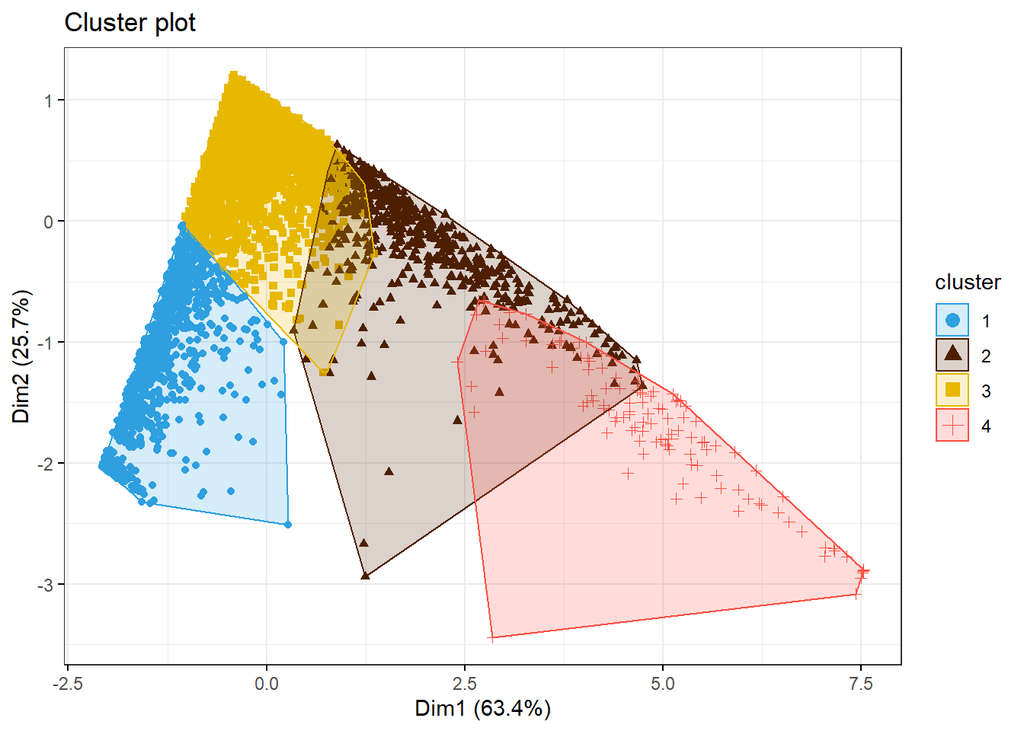

```r
fviz_cluster(km.out, data = RFM_Scaled_cluster.6[,c(1:3)],
             palette = c("#2E9FDF", "#4d1f00", "#E7B800","#ff5044" ),
             geom = "point",
             ellipse.type = "convex",
             ggtheme = theme_bw())
```

#### (Q6-4)Which of the clusters do you think are the most suitable for us to run target marketing campaigns and how?

-ANS:

cluster 4. Because the clients belonging to this cluster have more Average_Monetary, shopping Frequency than others. And the negative value of Recency reflects that the cluster of the customer is our recent clients.

(Because Recency is calculated by some fixed number - the last time user shopped)

Hence, the bigger the observation’s Recency is, the longer ago that client visit the store. And the observation in a cluster will form its own average value. That is the average value(or clusteriod)we get.

To sum up, the culster 4 has a small Recency indicates that they are current customers. And with high average frequency, which means they are frequent buyers.

In conclusion, cluster 4 is suitable for market campaigns.

#### (Q6- l) Based on the list of top selling products,

you could further develop your target marketing strategies. Print out the top 5 most selling products in terms of sales revenue (i.e., sum of sales amount = quantity x unit price) for each cluster.

```r
table_B<-data2.2; head(table_B,3)
```

```
##    InvoiceNo StockCode                        Description Quantity InvoiceDate
## 1:    536365    85123A WHITE HANGING HEART T-LIGHT HOLDER        6  2010-12-01
## 2:    536365     71053                WHITE METAL LANTERN        6  2010-12-01
## 3:    536365    84406B     CREAM CUPID HEARTS COAT HANGER        8  2010-12-01
##    UnitPrice CustomerID        Country Amount
## 1:      2.55      17850 United Kingdom  15.30
## 2:      3.39      17850 United Kingdom  20.34
## 3:      2.75      17850 United Kingdom  22.00
```

取得有customerId, 有cluster no的運算值

```r
RFM_Scaled_with_cluster  <- cbind(RFM_Scaled_save_Q6_l,cluster =unlist(Cluster_No));
head(RFM_Scaled_with_cluster,3)
```

```
##          CustomerID Monetary Frequency Recency cluster
## cluster1      12346     0.00         2     325       1
## cluster2      12347  4310.00       182       2       2
## cluster3      12348  1797.24        31      75       3
```

**Getting the desired df**

```r
#inner join Raw data with RFM_Scaled_with_cluster by CustomerID
full_raw_dataset <- merge(x = table_B, y = RFM_Scaled_with_cluster, by = "CustomerID", all = FALSE)
#All = True 表示Full outer Join


#str(RFM_Scaled_with_cluster)
head(full_raw_dataset, 3)
```

```
##    CustomerID InvoiceNo StockCode                     Description Quantity
## 1:      12346    541431     23166  MEDIUM CERAMIC TOP STORAGE JAR    74215
## 2:      12346   C541433     23166  MEDIUM CERAMIC TOP STORAGE JAR   -74215
## 3:      12347    537626     85116 BLACK CANDELABRA T-LIGHT HOLDER       12
##    InvoiceDate UnitPrice        Country   Amount Monetary Frequency Recency
## 1:  2011-01-18      1.04 United Kingdom  77183.6        0         2     325
## 2:  2011-01-18      1.04 United Kingdom -77183.6        0         2     325
## 3:  2010-12-07      2.10        Iceland     25.2     4310       182       2
##    cluster
## 1:       1
## 2:       1
## 3:       2
```

Part - *data cleaning for full_raw_dataset*

```r
#(1) remove the unnecessary col
full_data_stage_valid_col <- full_raw_dataset
full_data_stage_valid_col <- full_data_stage_valid_col[,Description :=NULL][,Country:=NULL]
head(full_data_stage_valid_col,3)
```

```
##    CustomerID InvoiceNo StockCode Quantity InvoiceDate UnitPrice   Amount
## 1:      12346    541431     23166    74215  2011-01-18      1.04  77183.6
## 2:      12346   C541433     23166   -74215  2011-01-18      1.04 -77183.6
## 3:      12347    537626     85116       12  2010-12-07      2.10     25.2
##    Monetary Frequency Recency cluster
## 1:        0         2     325       1
## 2:        0         2     325       1
## 3:     4310       182       2       2
```

- *datatype change*

```r
full_data_stage_valid_col <- full_data_stage_valid_col %>%
    mutate(InvoiceNo   = as.factor(InvoiceNo),
           StockCode   = as.factor(StockCode),
           CustomerID    = as.factor(CustomerID ));
full_dataset <- full_data_stage_valid_col
str(full_data_stage_valid_col)
```

```
## Classes 'data.table' and 'data.frame':   406829 obs. of  11 variables:
##  $ CustomerID : Factor w/ 4372 levels "12346","12347",..: 1 1 2 2 2 2 2 2 2 2 ...
##  $ InvoiceNo  : Factor w/ 22190 levels "536365","536366",..: 1910 18959 549 549 549 549 549 549 549 549 ...
##  $ StockCode  : Factor w/ 3684 levels "10002","10080",..: 2002 2002 3248 1251 2659 1357 1625 1626 1627 1628 ...
##  $ Quantity   : int  74215 -74215 12 4 12 36 12 12 12 12 ...
##  $ InvoiceDate: Date, format: "2011-01-18" "2011-01-18" ...
##  $ UnitPrice  : num  1.04 1.04 2.1 4.25 3.25 0.65 1.25 1.25 1.25 1.25 ...
##  $ Amount     : num  77183.6 -77183.6 25.2 17 39 ...
##  $ Monetary   : num  0 0 4310 4310 4310 4310 4310 4310 4310 4310 ...
##  $ Frequency  : num  2 2 182 182 182 182 182 182 182 182 ...
##  $ Recency    : num  325 325 2 2 2 2 2 2 2 2 ...
##  $ cluster    : int  1 1 2 2 2 2 2 2 2 2 ...
##  - attr(*, ".internal.selfref")=<externalptr>
##  - attr(*, "sorted")= chr "CustomerID"
```

#### Print out the top 5 most selling products in terms of sales revenue

#(i.e., sum of sales amount = quantity x unit price) for each cluster.

```r
cluster4_set_full.data =subset(full_dataset,cluster== 4)
cluster3_set_full.data =subset(full_dataset,cluster== 3)
cluster2_set_full.data =subset(full_dataset,cluster== 2)
cluster1_set_full.data =subset(full_dataset,cluster== 1)
```

#### cluster 1 part:

The code below would print out the top 10 best sales for cluster 1. However, we have to excludes the stockcode ‘M’,‘POST’ because they may represent some kind of trading code or itemsets instead of specific item. Therefore, if we neglect them, the rest top 5 best sales product are

```r
cluster1.top <- cluster1_set_full.data %>%
    group_by(StockCode)%>%
    summarise(Amount = sum(Amount),
              Quantity = sum(Quantity))%>%
    arrange(-(Amount))%>%  #set the order
    select(c(StockCode,Quantity, Amount))#Get the info we want via select


head(cluster1.top , 10)
```

```
## # A tibble: 10 x 3
##    StockCode Quantity Amount
##    <fct>        <int>  <dbl>
##  1 22502          322 41028.
##  2 22423          644  7721.
##  3 85123A        2032  5635.
##  4 47566         1031  4862.
##  5 POST           168  4057.
##  6 22197         4965  3635.
##  7 21621          376  2934.
##  8 22084          945  2532.
##  9 84879         1490  2518.
## 10 22328          967  2507.
```

#### cluster 2 part:

The top 5 product except the unknown trading code are:

```r
cluster2.top <- cluster2_set_full.data %>%
    group_by(StockCode)%>%
    summarise(Amount = sum(Amount),
              Quantity = sum(Quantity))%>%
    arrange(-(Amount))%>%
    select(c(StockCode,Quantity, Amount))


head(cluster2.top , 8)
```

```
## # A tibble: 8 x 3
##   StockCode Quantity Amount
##   <fct>        <int>  <dbl>
## 1 22423         2399 28155.
## 2 POST          1148 24054.
## 3 85123A        6266 17405.
## 4 47566         3419 15888.
## 5 85099B        7159 14180.
## 6 84879         8084 13470.
## 7 23084         5808 10804.
## 8 21137         2715  9356.
```

**Cluster 3:**

The top 5 product among the cluster 3 are:

```r
cluster3.top <- cluster3_set_full.data %>%
    group_by(StockCode)%>%
    summarise(Amount = sum(Amount),
              Quantity = sum(Quantity))%>%
    arrange(-(Amount))%>%
    select(c(StockCode,Quantity, Amount));head(cluster3.top , 10)
```

```
## # A tibble: 10 x 3
##    StockCode Quantity Amount
##    <fct>        <int>  <dbl>
##  1 22423         2330 27783.
##  2 POST          1137 27773.
##  3 85123A        8844 24489
##  4 85099B       11515 21999.
##  5 47566         4629 21291.
##  6 84879        11333 18577.
##  7 23084         9090 16773.
##  8 22086         5978 16387.
##  9 79321         2818 13464.
## 10 23355         2368 11011.
```

**cluster 4 part:**

Except the special trading code, the top 5 product among the cluster 4 are:

```r
cluster4.top <- cluster4_set_full.data %>%
    group_by(StockCode)%>%
    summarise(Amount = sum(Amount),
              Quantity = sum(Quantity))%>%
    arrange(-(Amount))%>%
    select(c(StockCode,Quantity, Amount));head(cluster4.top , 10)
```

```
## # A tibble: 10 x 3
##    StockCode Quantity Amount
##    <fct>        <int>  <dbl>
##  1 22423         6182 69210.
##  2 85123A       17062 46450.
##  3 85099B       25446 45278.
##  4 47566         5948 25646.
##  5 23084        12166 23499.
##  6 22386        13019 23175.
##  7 82484         4351 23092.
##  8 79321         4639 22048.
##  9 84879        14407 21934.
## 10 21137         6423 21875.
```

### Extra Credit:

- (EC1)Any seasonality (variation by month) in purchase frequency of the 5 top/best sellers. Compute purchase frequency of the top 5 selling products by month and visualize it using ggplot2.

First, Our goal is to group by month, however, we got 2 Dec data. Therefore, we shall make the time as year-month to distingish the 2010, 2011 Dec, otherwise, the value of Dec will be overestimated.

```r
temp <- as.yearmon(full_raw_dataset$InvoiceDate, '%Y-%m%-%d' )
```

Get the top 5 sale by amount among all the item first

```r
top_sale_all_year <- full_raw_dataset %>%
    mutate(Month_ = temp)%>% #add a new column 'Month_'
    group_by(StockCode)%>%
    summarise( Total_Amount = sum(Amount),
              Total_Frequency = sum(Frequency),)%>%
    arrange(-(Total_Amount))


Top_five <- head(top_sale_all_year,6)%>%
    filter(StockCode  != 'POST'); Top_five
```

```
## # A tibble: 5 x 3
##   StockCode Total_Amount Total_Frequency
##   <chr>            <dbl>           <dbl>
## 1 22423          132870.         456427.
## 2 85123A          93979.         546281.
## 3 85099B          83237.         482333.
## 4 47566           67688.         361604.
## 5 84879           56499.         303482.
```

```r
# top_sale_all_year <- full_raw_dataset %>%
#     mutate(Month_ = month(InvoiceDate) ) %>% #add a new column 'Month_'
#     group_by(StockCode)%>%
#     summarise( Total_Amount = sum(Amount),
#               Total_Frequency = sum(Frequency),) %>%
#     arrange(-(Total_Amount))
# Top_five <- head(top_sale_all_year,6); Top_five

#Excludes StockCode 'POST' and send the vector into a vector to store
top_sale_itemset <- unlist(Top_five%>%select(StockCode))
top_sale_itemset
```

```
## StockCode1 StockCode2 StockCode3 StockCode4 StockCode5
##    "22423"   "85123A"   "85099B"    "47566"    "84879"
```

we filter out the data we need from the top_sale_itemset(the one with ‘Month_’)

because the data we have is 2010/12 -2011/12, therefore, we may get multiple Dec data if we only use the function month directly. We need to use Year-Date format.

```r
data_top_sale_only <- full_raw_dataset %>%
    mutate(Month_ = as.yearmon(full_raw_dataset$InvoiceDate, '%Y-%m%-%d' ) ) %>%
    filter(StockCode %in% top_sale_itemset) %>%
    select(c(StockCode,Quantity,Amount,Frequency,Month_))

head(data_top_sale_only,6)
```

```
##    StockCode Quantity Amount Frequency      Month_
## 1:     22423        3  38.25       182   一月 2011
## 2:     22423        3  38.25       182   四月 2011
## 3:     22423        3  38.25       182   八月 2011
## 4:     22423        6  76.50       182   十月 2011
## 5:     22423        1  12.75        73 十一月 2011
## 6:     22423        3  38.25        95   二月 2011
```

#### Clarification

Before we start, let me clarify first: To count how many items for the specific item were purchased during the specific month, only sum up the Quantity makes more sense. Because if we replace it with sum(Frequency), it only reflects the trading hobby. The frequency is the times customer visits the store and shop for a specific item. The customer can buy a item at a massive scale at a single time. However, the frequency would only count 1 time because all of them are belong to a single transaction. And it may effect by the regional difference, instead of seasonal reason.

Therefore, the shopping quantity can reflect the seasonal demand in the market more directly in my opinion.

```r
Total_df <-data_top_sale_only %>%
    group_by(Month_, StockCode)%>%
    summarise(Total_Amount = sum(Amount),
               Total_Frequency = sum(Frequency),
              Total_quantity = sum(Quantity ))
head(Total_df,3)
```

```
## # A tibble: 3 x 5
## # Groups:   Month_ [1]
##   Month_      StockCode Total_Amount Total_Frequency Total_quantity
##   <yearmon>   <chr>            <dbl>           <dbl>          <int>
## 1 十二月 2010 22423           16784.          37366.           1492
## 2 十二月 2010 47566             794.           5287.            190
## 3 十二月 2010 84879            3666.          20342.           2267
```

plot them with different colur by group (StockCode)

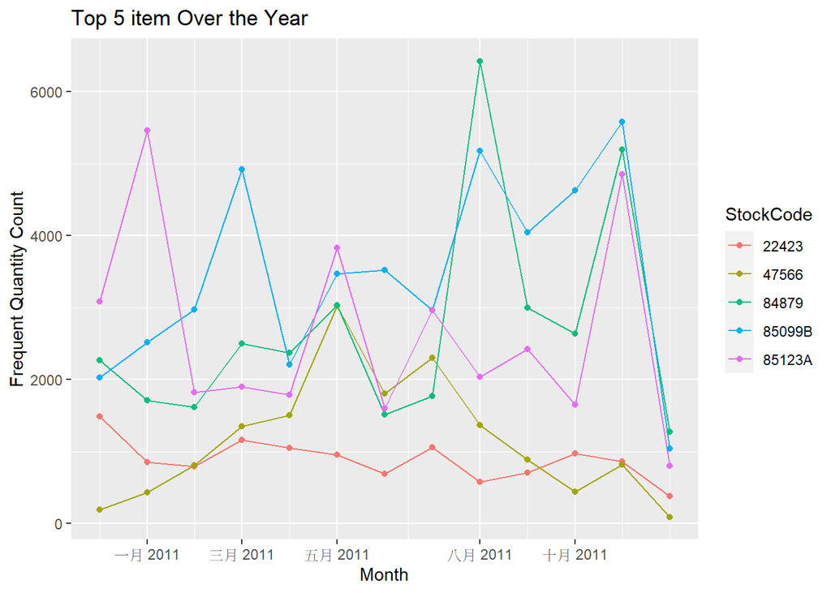

```r
Total_plot <-Total_df %>%
    ggplot(aes(x = Month_ ,
               y = Total_quantity,colour = StockCode,group = StockCode )) +
    geom_line()+
    geom_point()+
    labs(x = 'Month',
         y = 'Frequent Quantity Count',
         title = 'Top 5 item Over the Year')
Total_plot
```

### EC2) Do we observe any seasonality? Please explain verbally.

Yes. The sales of the stock 85123A seems that roaring as the winter period. And the item 47566 appears to have a high demand in the market during the period of April ~ July

Last but not least, the peak of the item 85099 seems have high demand in the winter time these two year.

**Explain whether k = 4 is a reasonable decision using the Elbow/Silhouette method.**

Let see what is the current clustering status:

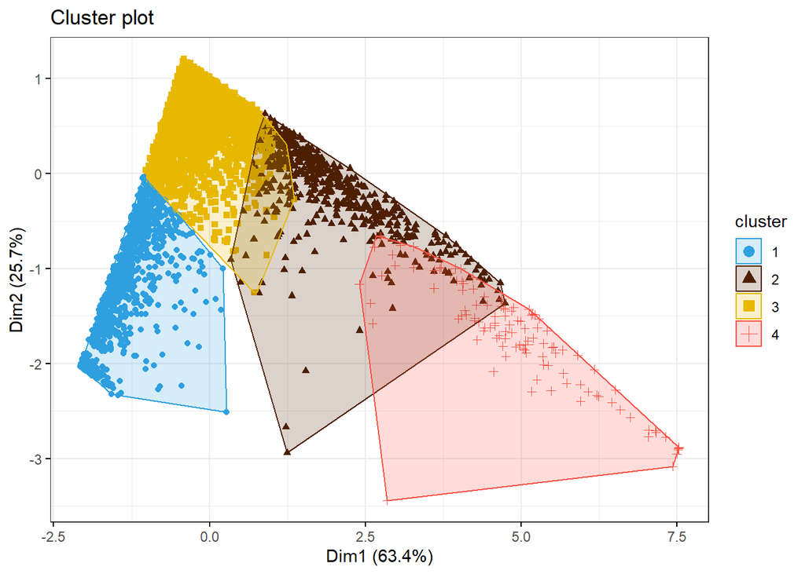

```r
fviz_cluster(km.out, data = RFM_Scaled_cluster.6[,c(1:3)],
             palette = c("#2E9FDF", "#4d1f00", "#E7B800","#ff5044" ),
             geom = "point",
             ellipse.type = "convex",
             ggtheme = theme_bw())
```

#### Note:

**To achieve the better k value, our goal is to make the variance inside a cluster as small as it can. And make the difference among the cluster as larger as it can**

#### Elbow Method Part:

We want to select the number of K where the WSS starts to go flat dramatically. In this plot, I would say it quite ambiguous for the chosen of K =3 or K=4. It seems that k=4 is better than k=3.

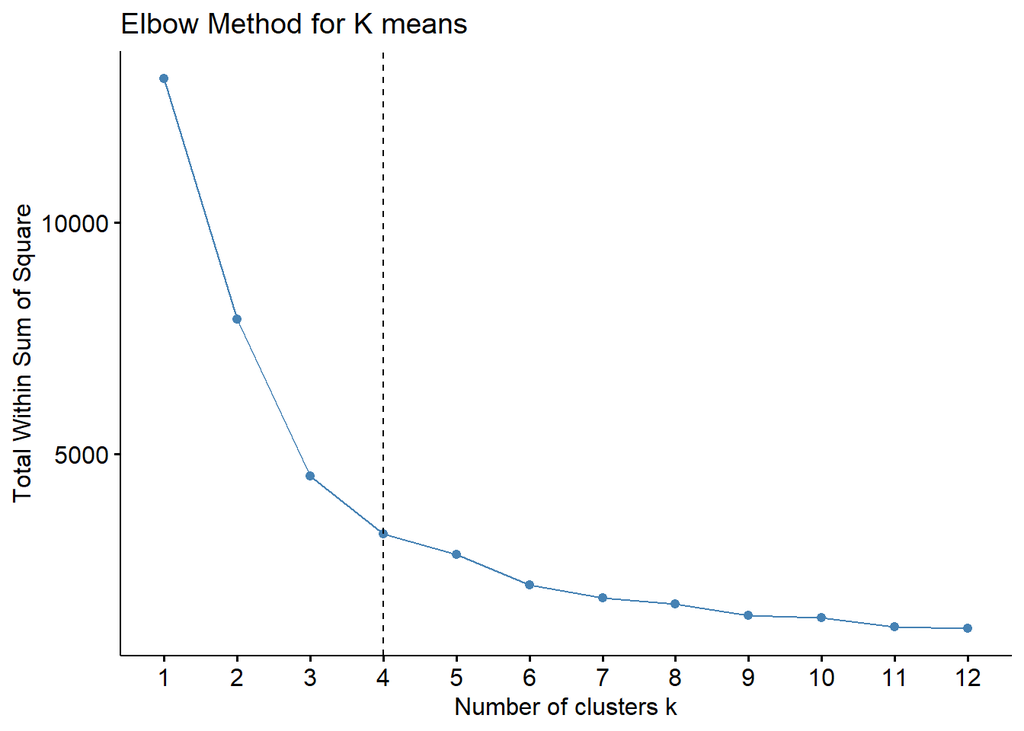

```r
require(ggplot2)
fviz_nbclust(RFM_Scaled_cluster.6[,c(1:3)],
             FUNcluster = kmeans,
             method = "wss",     # the sum of the Squared Errors for all the points.
             k.max = 12          # max number of clusters to consider
             ) + labs(title="Elbow Method for K means")+
             geom_vline(xintercept = 4,linetype = 2)
```

For the part of Silhouette, this part we are testing the cohesion inside the cluster.

Appearently, as K= 4, and K=3, the average Silhouette witdth reach the high peak.

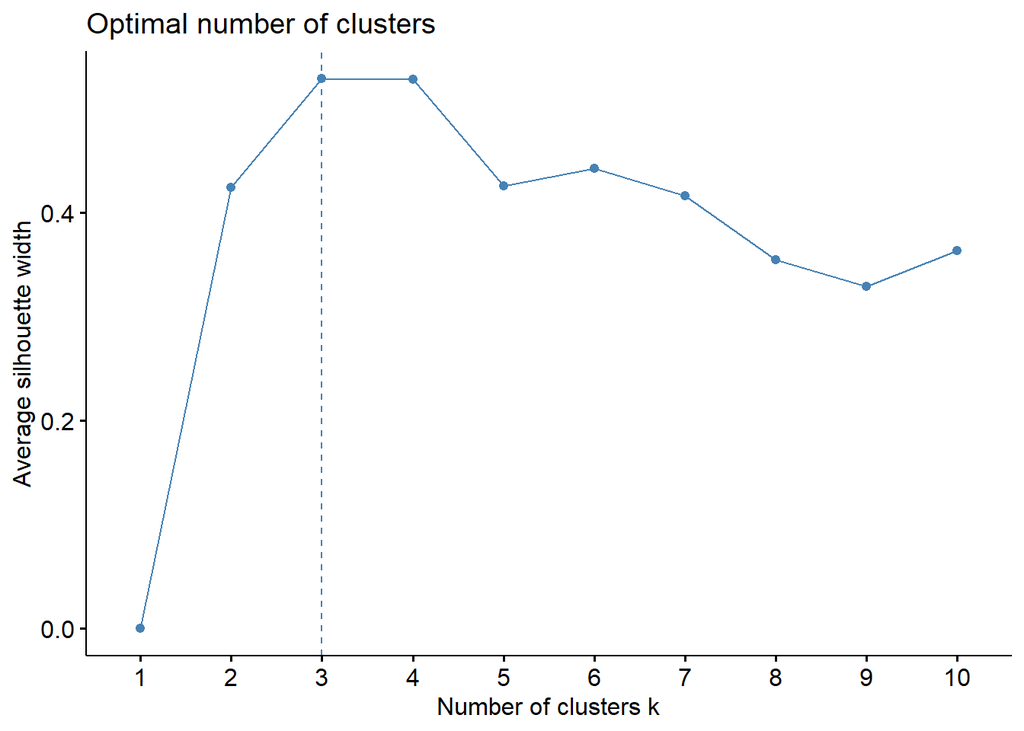

```r
# The more value we get from Silhouette is closer from 1, the more we desired for.

library (cluster)
set.seed(2021)
fviz_nbclust(RFM_Scaled_cluster.6[,c(1:3)],
             FUNcluster = kmeans,
             method = "silhouette")
```